# Investigate a Dataset (Tmdb-Movies Dataset)

# AMR SAAD MAHMOUD

Table of Contents¶

I-ntroduction

2-Data Wrangling

3-Exploratory Data Analysis

4-Conclusions

# 1-introduction

dataset Contain:

Total Rows = 10866

Total Columns = 21

After Seeing the dataset we can say that some columns is contain null values

Questions answered by the dataset

Which year has the highest release of movies?

Which Movie Has The Highest Or Lowest Profit? Top 10 movies which earn highest profit?

Movie with Highest And Lowest Budget?

Which movie made the highest revenue and lowest as well?

Movie with shorest and longest runtime?

Which movie get the highest or lowest votes (Ratings).

Which Year Has The Highest Profit Rate?

Which length movies most liked by the audiences according to their popularity?

Average Runtime Of Movies From Year To Year?

How Does The Revenue And Popularity differs Budget And Runtime? And How Does Popularity Depends On Profit?

Which Month Released Highest Number Of Movies In All Of The Years? And Which Month Made The Highest Average Revenue?

Which Genre Has The Highest Release Of Movies?

Which genres are most popular from year to year?

Most Frequent star cast?

Top 20 Production Companies With Higher Number Of Release?

Life Time Profit Earn By Each Production Company?

Top 20 Director Who Directs Maximum Movies?

What kinds of properties are associated with movies that have high revenues?

```python
#import packedg
import pandas as pd
import numpy as np
import matplotlib.pyplot as plt
import seaborn as sb

%matplotlib inline
```

# 2-Data Wrangling

```python
#import dataset
df=pd.read_csv("C:/Users/amr/Desktop/tmdb_movies_data.csv")
df.head(5)
```

|  | id | imdb_id | popularity | budget | revenue | original_title | cast | homepage | director | tagline | ... | overview | runtime | genres | production_companies | release_date | vote_count | vote_average | release_year | budget_adj | revenue_adj |
| --- | --- | --- | --- | --- | --- | --- | --- | --- | --- | --- | --- | --- | --- | --- | --- | --- | --- | --- | --- | --- | --- |
| 0 | 135397 | tt0369610 | 32.985763 | 150000000 | 1513528810 | Jurassic World | Chris Pratt\|Bryce Dallas Howard\|Irrfan Khan\|Vi... | http://www.jurassicworld.com/ | Colin Trevorrow | The park is open. | ... | Twenty-two years after the events of Jurassic ... | 124 | Action\|Adventure\|Science Fiction\|Thriller | Universal Studios\|Amblin Entertainment\|Legenda... | 6/9/2015 | 5562 | 6.5 | 2015 | 137999939.3 | 1.392446e+09 |
| 1 | 76341 | tt1392190 | 28.419936 | 150000000 | 378436354 | Mad Max: Fury Road | Tom Hardy\|Charlize Theron\|Hugh Keays-Byrne\|Nic... | http://www.madmaxmovie.com/ | George Miller | What a Lovely Day. | ... | An apocalyptic story set in the furthest reach... | 120 | Action\|Adventure\|Science Fiction\|Thriller | Village Roadshow Pictures\|Kennedy Miller Produ... | 5/13/2015 | 6185 | 7.1 | 2015 | 137999939.3 | 3.481613e+08 |
| 2 | 262500 | tt2908446 | 13.112507 | 110000000 | 295238201 | Insurgent | Shailene Woodley\|Theo James\|Kate Winslet\|Ansel... | http://www.thedivergentseries.movie/#insurgent | Robert Schwentke | One Choice Can Destroy You | ... | Beatrice Prior must confront her inner demons ... | 119 | Adventure\|Science Fiction\|Thriller | Summit Entertainment\|Mandeville Films\|Red Wago... | 3/18/2015 | 2480 | 6.3 | 2015 | 101199955.5 | 2.716190e+08 |
| 3 | 140607 | tt2488496 | 11.173104 | 200000000 | 2068178225 | Star Wars: The Force Awakens | Harrison Ford\|Mark Hamill\|Carrie Fisher\|Adam D... | http://www.starwars.com/films/star-wars-episod... | J.J. Abrams | Every generation has a story. | ... | Thirty years after defeating the Galactic Empi... | 136 | Action\|Adventure\|Science Fiction\|Fantasy | Lucasfilm\|Truenorth Productions\|Bad Robot | 12/15/2015 | 5292 | 7.5 | 2015 | 183999919.0 | 1.902723e+09 |
| 4 | 168259 | tt2820852 | 9.335014 | 190000000 | 1506249360 | Furious 7 | Vin Diesel\|Paul Walker\|Jason Statham\|Michelle ... | http://www.furious7.com/ | James Wan | Vengeance Hits Home | ... | Deckard Shaw seeks revenge against Dominic Tor... | 137 | Action\|Crime\|Thriller | Universal Pictures\|Original Film\|Media Rights ... | 4/1/2015 | 2947 | 7.3 | 2015 | 174799923.1 | 1.385749e+09 |

5 rows × 21 columns

```python
df.tail(5)
```

|  | id | imdb_id | popularity | budget | revenue | original_title | cast | homepage | director | tagline | ... | overview | runtime | genres | production_companies | release_date | vote_count | vote_average | release_year | budget_adj | revenue_adj |
| --- | --- | --- | --- | --- | --- | --- | --- | --- | --- | --- | --- | --- | --- | --- | --- | --- | --- | --- | --- | --- | --- |
| 10861 | 21 | tt0060371 | 0.080598 | 0 | 0 | The Endless Summer | Michael Hynson\|Robert August\|Lord 'Tally Ho' B... | NaN | Bruce Brown | NaN | ... | The Endless Summer, by Bruce Brown, is one of ... | 95 | Documentary | Bruce Brown Films | 6/15/1966 | 11 | 7.4 | 1966 | 0.0000 | 0.0 |
| 10862 | 20379 | tt0060472 | 0.065543 | 0 | 0 | Grand Prix | James Garner\|Eva Marie Saint\|Yves Montand\|Tosh... | NaN | John Frankenheimer | Cinerama sweeps YOU into a drama of speed and ... | ... | Grand Prix driver Pete Aron is fired by his te... | 176 | Action\|Adventure\|Drama | Cherokee Productions\|Joel Productions\|Douglas ... | 12/21/1966 | 20 | 5.7 | 1966 | 0.0000 | 0.0 |
| 10863 | 39768 | tt0060161 | 0.065141 | 0 | 0 | Beregis Avtomobilya | Innokentiy Smoktunovskiy\|Oleg Efremov\|Georgi Z... | NaN | Eldar Ryazanov | NaN | ... | An insurance agent who moonlights as a carthie... | 94 | Mystery\|Comedy | Mosfilm | 1/1/1966 | 11 | 6.5 | 1966 | 0.0000 | 0.0 |
| 10864 | 21449 | tt0061177 | 0.064317 | 0 | 0 | What's Up, Tiger Lily? | Tatsuya Mihashi\|Akiko Wakabayashi\|Mie Hama\|Joh... | NaN | Woody Allen | WOODY ALLEN STRIKES BACK! | ... | In comic Woody Allen's film debut, he took the... | 80 | Action\|Comedy | Benedict Pictures Corp. | 11/2/1966 | 22 | 5.4 | 1966 | 0.0000 | 0.0 |
| 10865 | 22293 | tt0060666 | 0.035919 | 19000 | 0 | Manos: The Hands of Fate | Harold P. Warren\|Tom Neyman\|John Reynolds\|Dian... | NaN | Harold P. Warren | It's Shocking! It's Beyond Your Imagination! | ... | A family gets lost on the road and stumbles up... | 74 | Horror | Norm-Iris | 11/15/1966 | 15 | 1.5 | 1966 | 127642.2792 | 0.0 |

5 rows × 21 columns

```python
df.info()
```

```
<class 'pandas.core.frame.DataFrame'>
RangeIndex: 10866 entries, 0 to 10865
Data columns (total 21 columns):
id                      10866 non-null int64
imdb_id                 10856 non-null object
popularity              10866 non-null float64
budget                  10866 non-null int64
revenue                 10866 non-null int64
original_title          10866 non-null object
cast                    10790 non-null object
homepage                2936 non-null object
director                10822 non-null object
tagline                 8042 non-null object
keywords                9373 non-null object
overview                10862 non-null object
runtime                 10866 non-null int64
genres                  10843 non-null object
production_companies    9836 non-null object
release_date            10866 non-null object
vote_count              10866 non-null int64
vote_average            10866 non-null float64
release_year            10866 non-null int64
budget_adj              10866 non-null float64
revenue_adj             10866 non-null float64
dtypes: float64(4), int64(6), object(11)
memory usage: 1.7+ MB
```

```python
df.describe()
```

|  | id | popularity | budget | revenue | runtime | vote_count | vote_average | release_year | budget_adj | revenue_adj |
| --- | --- | --- | --- | --- | --- | --- | --- | --- | --- | --- |
| count | 10866.000000 | 10866.000000 | 1.086600e+04 | 1.086600e+04 | 10866.000000 | 10866.000000 | 10866.000000 | 10866.000000 | 1.086600e+04 | 1.086600e+04 |
| mean | 66064.177434 | 0.646441 | 1.462570e+07 | 3.982332e+07 | 102.070863 | 217.389748 | 5.974922 | 2001.322658 | 1.755104e+07 | 5.136436e+07 |
| std | 92130.136561 | 1.000185 | 3.091321e+07 | 1.170035e+08 | 31.381405 | 575.619058 | 0.935142 | 12.812941 | 3.430616e+07 | 1.446325e+08 |
| min | 5.000000 | 0.000065 | 0.000000e+00 | 0.000000e+00 | 0.000000 | 10.000000 | 1.500000 | 1960.000000 | 0.000000e+00 | 0.000000e+00 |
| 25% | 10596.250000 | 0.207583 | 0.000000e+00 | 0.000000e+00 | 90.000000 | 17.000000 | 5.400000 | 1995.000000 | 0.000000e+00 | 0.000000e+00 |
| 50% | 20669.000000 | 0.383856 | 0.000000e+00 | 0.000000e+00 | 99.000000 | 38.000000 | 6.000000 | 2006.000000 | 0.000000e+00 | 0.000000e+00 |
| 75% | 75610.000000 | 0.713817 | 1.500000e+07 | 2.400000e+07 | 111.000000 | 145.750000 | 6.600000 | 2011.000000 | 2.085325e+07 | 3.369710e+07 |
| max | 417859.000000 | 32.985763 | 4.250000e+08 | 2.781506e+09 | 900.000000 | 9767.000000 | 9.200000 | 2015.000000 | 4.250000e+08 | 2.827124e+09 |

```python
df.isnull().sum()
```

```
id                         0
imdb_id                   10
popularity                 0
budget                     0
revenue                    0
original_title             0
cast                      76
homepage                7930
director                  44
tagline                 2824
keywords                1493
overview                   4
runtime                    0
genres                    23
production_companies    1030
release_date               0
vote_count                 0
vote_average               0
release_year               0
budget_adj                 0
revenue_adj                0
dtype: int64
```

Data Cleaning (Removing The Unused Information From The Dataset)

Information That We Need To Delete Or Modify

We need to remove duplicate rows from the dataset

Changing format of release date into datetime format

Remove the unused colums that are not needes in the analysis process.

Remove the movies which are having zero value of budget and revenue

```python
#remove duplicate rows from the dataset
df.duplicated().sum()
```

```
1
```

```python
#code
df.drop_duplicates(inplace=True)
```

```python
#test
df.duplicated().sum()
```

```
0
```

```python
#Changing format of release date into datetime format
#code
df.release_date=pd.to_datetime(df.release_date)
```

```python
#test
df.release_date.head(5)
```

```
0   2015-06-09
1   2015-05-13
2   2015-03-18
3   2015-12-15
4   2015-04-01
Name: release_date, dtype: datetime64[ns]
```

```python
#Remove the unused colums that are not needes in the analysis process

#code
df.drop(['budget_adj','revenue_adj','overview','imdb_id','homepage','tagline'],axis =1,inplace = True)
```

```python
#test
df.head(5)
```

|  | id | popularity | budget | revenue | original_title | cast | director | keywords | runtime | genres | production_companies | release_date | vote_count | vote_average | release_year |
| --- | --- | --- | --- | --- | --- | --- | --- | --- | --- | --- | --- | --- | --- | --- | --- |
| 0 | 135397 | 32.985763 | 150000000 | 1513528810 | Jurassic World | Chris Pratt\|Bryce Dallas Howard\|Irrfan Khan\|Vi... | Colin Trevorrow | monster\|dna\|tyrannosaurus rex\|velociraptor\|island | 124 | Action\|Adventure\|Science Fiction\|Thriller | Universal Studios\|Amblin Entertainment\|Legenda... | 2015-06-09 | 5562 | 6.5 | 2015 |
| 1 | 76341 | 28.419936 | 150000000 | 378436354 | Mad Max: Fury Road | Tom Hardy\|Charlize Theron\|Hugh Keays-Byrne\|Nic... | George Miller | future\|chase\|post-apocalyptic\|dystopia\|australia | 120 | Action\|Adventure\|Science Fiction\|Thriller | Village Roadshow Pictures\|Kennedy Miller Produ... | 2015-05-13 | 6185 | 7.1 | 2015 |
| 2 | 262500 | 13.112507 | 110000000 | 295238201 | Insurgent | Shailene Woodley\|Theo James\|Kate Winslet\|Ansel... | Robert Schwentke | based on novel\|revolution\|dystopia\|sequel\|dyst... | 119 | Adventure\|Science Fiction\|Thriller | Summit Entertainment\|Mandeville Films\|Red Wago... | 2015-03-18 | 2480 | 6.3 | 2015 |
| 3 | 140607 | 11.173104 | 200000000 | 2068178225 | Star Wars: The Force Awakens | Harrison Ford\|Mark Hamill\|Carrie Fisher\|Adam D... | J.J. Abrams | android\|spaceship\|jedi\|space opera\|3d | 136 | Action\|Adventure\|Science Fiction\|Fantasy | Lucasfilm\|Truenorth Productions\|Bad Robot | 2015-12-15 | 5292 | 7.5 | 2015 |
| 4 | 168259 | 9.335014 | 190000000 | 1506249360 | Furious 7 | Vin Diesel\|Paul Walker\|Jason Statham\|Michelle ... | James Wan | car race\|speed\|revenge\|suspense\|car | 137 | Action\|Crime\|Thriller | Universal Pictures\|Original Film\|Media Rights ... | 2015-04-01 | 2947 | 7.3 | 2015 |

```python
#Remove the movies which are having zero value of budget and revenue

#code
zero_list=['budget','revenue']
df[zero_list]=df[zero_list].replace(0,np.nan)
df.dropna(subset=zero_list,inplace=True)
```

```python
#test
df[df['budget']==0]
```

|  | id | popularity | budget | revenue | original_title | cast | director | keywords | runtime | genres | production_companies | release_date | vote_count | vote_average | release_year |
| --- | --- | --- | --- | --- | --- | --- | --- | --- | --- | --- | --- | --- | --- | --- | --- |

# 3-Exploratory Data Analysis

# Which year has the highest release of movies?

```
release_year
2011    199
2012    158
2013    180
2014    165
2015    160
Name: id, dtype: int64
```

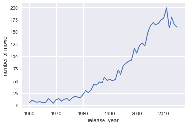

```python
#code
high_year=df.groupby('release_year').count()['id']
print(data.tail())

plt.xlabel("release_year")
plt.ylabel("number of movie")
plt.plot(high_year)
```

```python
high_year.idxmax()
```

```
2011
```

# Research Question 2 : Which Movie Has The Highest Or Lowest Profit?

```python
df['profit']=df['revenue']-df['budget']
df.head(2)
```

|  | id | popularity | budget | revenue | original_title | cast | director | keywords | runtime | genres | production_companies | release_date | vote_count | vote_average | release_year | profit |
| --- | --- | --- | --- | --- | --- | --- | --- | --- | --- | --- | --- | --- | --- | --- | --- | --- |
| 0 | 135397 | 32.985763 | 150000000.0 | 1.513529e+09 | Jurassic World | Chris Pratt\|Bryce Dallas Howard\|Irrfan Khan\|Vi... | Colin Trevorrow | monster\|dna\|tyrannosaurus rex\|velociraptor\|island | 124 | Action\|Adventure\|Science Fiction\|Thriller | Universal Studios\|Amblin Entertainment\|Legenda... | 2015-06-09 | 5562 | 6.5 | 2015 | 1.363529e+09 |
| 1 | 76341 | 28.419936 | 150000000.0 | 3.784364e+08 | Mad Max: Fury Road | Tom Hardy\|Charlize Theron\|Hugh Keays-Byrne\|Nic... | George Miller | future\|chase\|post-apocalyptic\|dystopia\|australia | 120 | Action\|Adventure\|Science Fiction\|Thriller | Village Roadshow Pictures\|Kennedy Miller Produ... | 2015-05-13 | 6185 | 7.1 | 2015 | 2.284364e+08 |

```python
#method one
print(df.profit.max())
print(df.profit.min())
```

```
2544505847.0
-413912431.0
```

```python
df[df['profit']==2544505847.0]
```

|  | id | popularity | budget | revenue | original_title | cast | director | keywords | runtime | genres | production_companies | release_date | vote_count | vote_average | release_year | profit |
| --- | --- | --- | --- | --- | --- | --- | --- | --- | --- | --- | --- | --- | --- | --- | --- | --- |
| 1386 | 19995 | 9.432768 | 237000000.0 | 2.781506e+09 | Avatar | Sam Worthington\|Zoe Saldana\|Sigourney Weaver\|S... | James Cameron | culture clash\|future\|space war\|space colony\|so... | 162 | Action\|Adventure\|Fantasy\|Science Fiction | Ingenious Film Partners\|Twentieth Century Fox ... | 2009-12-10 | 8458 | 7.1 | 2009 | 2.544506e+09 |

```python
df[df['profit']==-413912431.0]
```

|  | id | popularity | budget | revenue | original_title | cast | director | keywords | runtime | genres | production_companies | release_date | vote_count | vote_average | release_year | profit |
| --- | --- | --- | --- | --- | --- | --- | --- | --- | --- | --- | --- | --- | --- | --- | --- | --- |
| 2244 | 46528 | 0.25054 | 425000000.0 | 11087569.0 | The Warrior's Way | Kate Bosworth\|Jang Dong-gun\|Geoffrey Rush\|Dann... | Sngmoo Lee | assassin\|small town\|revenge\|deception\|super speed | 100 | Adventure\|Fantasy\|Action\|Western\|Thriller | Boram Entertainment Inc. | 2010-12-02 | 74 | 6.4 | 2010 | -413912431.0 |

```python
#method two
def high_mini(colomn):
    high_index=df[colomn].idxmax()
    mini_index=df[colomn].idxmin()
    high=pd.DataFrame(df.loc[high_index,:])
    low=pd.DataFrame(df.loc[mini_index,:])

    return high,low;

print(high_mini('profit'))
```

```
(                                                                   1386
id                                                                19995
popularity                                                      9.43277
budget                                                         2.37e+08
revenue                                                     2.78151e+09
original_title                                                   Avatar
cast                  Sam Worthington|Zoe Saldana|Sigourney Weaver|S...
director                                                  James Cameron
keywords              culture clash|future|space war|space colony|so...
runtime                                                             162
genres                         Action|Adventure|Fantasy|Science Fiction
production_companies  Ingenious Film Partners|Twentieth Century Fox ...
release_date                                        2009-12-10 00:00:00
vote_count                                                         8458
vote_average                                                        7.1
release_year                                                       2009
profit                                                      2.54451e+09,                                                                    2244
id                                                                46528
popularity                                                      0.25054
budget                                                         4.25e+08
revenue                                                     1.10876e+07
original_title                                        The Warrior's Way
cast                  Kate Bosworth|Jang Dong-gun|Geoffrey Rush|Dann...
director                                                     Sngmoo Lee
keywords              assassin|small town|revenge|deception|super speed
runtime                                                             100
genres                        Adventure|Fantasy|Action|Western|Thriller
production_companies                           Boram Entertainment Inc.
release_date                                        2010-12-02 00:00:00
vote_count                                                           74
vote_average                                                        6.4
release_year                                                       2010
profit                                                     -4.13912e+08)
```

# Movie with Highest And Lowest Budget?

```python
print(high_mini('budget'))
```

```
(                                                                   2244
id                                                                46528
popularity                                                      0.25054
budget                                                         4.25e+08
revenue                                                     1.10876e+07
original_title                                        The Warrior's Way
cast                  Kate Bosworth|Jang Dong-gun|Geoffrey Rush|Dann...
director                                                     Sngmoo Lee
keywords              assassin|small town|revenge|deception|super speed
runtime                                                             100
genres                        Adventure|Fantasy|Action|Western|Thriller
production_companies                           Boram Entertainment Inc.
release_date                                        2010-12-02 00:00:00
vote_count                                                           74
vote_average                                                        6.4
release_year                                                       2010
profit                                                     -4.13912e+08,                                                                    2618
id                                                                39964
popularity                                                     0.090186
budget                                                                1
revenue                                                             100
original_title                                             Lost & Found
cast                  David Spade|Sophie Marceau|Ever Carradine|Step...
director                                                   Jeff Pollack
keywords                                   restaurant|neighbor|dog|ring
runtime                                                              95
genres                                                   Comedy|Romance
production_companies           Alcon Entertainment|Dinamo Entertainment
release_date                                        1999-04-23 00:00:00
vote_count                                                           14
vote_average                                                        4.8
release_year                                                       1999
profit                                                               99)
```

# Which movie made the highest revenue and lowest as well?

```python
print(high_mini('revenue'))
```

```
(                                                                   1386
id                                                                19995
popularity                                                      9.43277
budget                                                         2.37e+08
revenue                                                     2.78151e+09
original_title                                                   Avatar
cast                  Sam Worthington|Zoe Saldana|Sigourney Weaver|S...
director                                                  James Cameron
keywords              culture clash|future|space war|space colony|so...
runtime                                                             162
genres                         Action|Adventure|Fantasy|Science Fiction
production_companies  Ingenious Film Partners|Twentieth Century Fox ...
release_date                                        2009-12-10 00:00:00
vote_count                                                         8458
vote_average                                                        7.1
release_year                                                       2009
profit                                                      2.54451e+09,                                                                    5067
id                                                                13537
popularity                                                     0.462609
budget                                                            6e+06
revenue                                                               2
original_title                                          Shattered Glass
cast                  Hayden Christensen|Peter Sarsgaard|ChloÃ« Sevi...
director                                                      Billy Ray
keywords                                                            NaN
runtime                                                              94
genres                                                    Drama|History
production_companies  Lions Gate Films|Cruise/Wagner Productions|Bau...
release_date                                        2003-11-14 00:00:00
vote_count                                                           46
vote_average                                                        6.4
release_year                                                       2003
profit                                                           -6e+06)
```

```python
df['runtime']=df['runtime'].replace(0,np.nan)
```

# Movie with shorest and longest runtime?

```python
print(high_mini('runtime'))
```

```
(                                                                   2107
id                                                                43434
popularity                                                     0.534192
budget                                                          1.8e+07
revenue                                                          871279
original_title                                                   Carlos
cast                  Edgar RamÃrez|Alexander Scheer|Fadi Abi Samra...
director                                                Olivier Assayas
keywords                     gun|car bomb|tv mini-series|terrorism|opec
runtime                                                             338
genres                                     Crime|Drama|Thriller|History
production_companies  Egoli Tossell Film AG|Canal+|Arte France|Films...
release_date                                        2010-05-19 00:00:00
vote_count                                                           35
vote_average                                                        6.2
release_year                                                       2010
profit                                                     -1.71287e+07,                                                                    5162
id                                                                24914
popularity                                                     0.208637
budget                                                               10
revenue                                                               5
original_title                                              Kid's Story
cast                  Clayton Watson|Keanu Reeves|Carrie-Anne Moss|K...
director                                            Shinichiro Watanabe
keywords                                                            NaN
runtime                                                              15
genres                                        Science Fiction|Animation
production_companies                                        Studio 4Â°C
release_date                                        2003-06-02 00:00:00
vote_count                                                           16
vote_average                                                        6.8
release_year                                                       2003
profit                                                               -5)
```

# Which movie get the highest or lowest votes (Ratings)

```python
print(high_mini('vote_average'))
```

```
(                                                                   4178
id                                                                  278
popularity                                                      7.19204
budget                                                          2.5e+07
revenue                                                     2.83415e+07
original_title                                 The Shawshank Redemption
cast                  Tim Robbins|Morgan Freeman|Bob Gunton|William ...
director                                                 Frank Darabont
keywords              prison|corruption|police brutality|prison cell...
runtime                                                             142
genres                                                      Drama|Crime
production_companies                          Castle Rock Entertainment
release_date                                        1994-09-10 00:00:00
vote_count                                                         5754
vote_average                                                        8.4
release_year                                                       1994
profit                                                      3.34147e+06,                                                                    4859
id                                                               116977
popularity                                                     0.111351
budget                                                          6.5e+07
revenue                                                           73706
original_title                                               Foodfight!
cast                  Charlie Sheen|Wayne Brady|Hilary Duff|Eva Long...
director                                              Lawrence Kasanoff
keywords              supermarket|fight|product placement|computer a...
runtime                                                              87
genres                                   Animation|Action|Comedy|Family
production_companies  Threshold Entertainment|Lions Gate Family Ente...
release_date                                        2012-06-15 00:00:00
vote_count                                                           12
vote_average                                                        2.2
release_year                                                       2012
profit                                                     -6.49263e+07)
```

# Which Year Has The Highest Profit Rate?

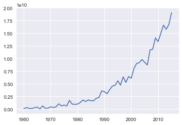

```python
year_profit=df.groupby('release_year')['profit'].sum()
plt.plot(year_profit)
```

```python
year_profit.idxmax()
```

```
2015
```

# Which length movies most liked by the audiences according to their popularity?

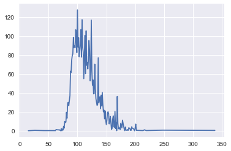

```python
lenght_runtime=df.groupby('runtime')['popularity'].sum()
plt.plot(lenght_runtime)
```

# Average Runtime Of Movies From Year To Year?

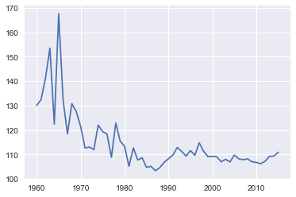

```python
runtime_year=df.groupby('release_year')['runtime'].mean()
plt.plot(runtime_year)
```